# Task 2: Hierarchical Clustering

Katheryn Moya

2/28/2023

## Overview:

This analysis conducts a multivariate clustering for water chemistry for each site in the Santa Barbara Coastal drainage area using data provided by the Santa Barbara Coastal Long-term Ecological Research station. Water samples across each of the 13 sites are collected weekly during non-storm flows in the winter and biweekly during the summer, variables measured include dissolved nitrogen, soluble reactive phosphorus , particulate organic carbon, nitrogen, and phosphorus, total suspended sediments, and conductivity. Hierarchical clustering was selected for this clustering analysis given the small sample size.

**Data citation:** Santa Barbara Coastal LTER and J. Melack. 2019. SBC LTER: Land: Stream chemistry in the Santa Barbara Coastal drainage area, ongoing since 2000 ver 16. Environmental Data Initiative. https://doi.org/10.6073/pasta/67a558a24ceed9a0a5bf5e46ab841174.

## Data Wrangling

```r
knitr::opts_chunk$set(echo = TRUE, warning = FALSE, message = TRUE)

library(tidyverse)
library(here)
library(janitor)

## packages for cluster analysis, extend our options for visualizations, etc

library(NbClust)
library(cluster)
library(factoextra) #for visualizing dendrograms
library(dendextend)
library(ggdendro)
library(paletteer)
```

In order to compare water chemistry observations across the drainage area, we must first create a data frame that has a single summary row per site based on means from all observations at that site. This involves using the `group_by()` and `summarize` function. Because NA values must be removed in order to re-scale the data, the following variables were excluded from the analysis to prevent dropping site observations: Total Particulate Carbon in micro-moles per liter (tpc_uM), Total Particulate Nitrogen in micro-moles per liter (tpn_uM), total particulate phosphorous micro-moles per liter (tpp_uM), total suspended solids in milligrams per liter (tss_mg_per_L), and specific conductivity in micro-Siemens per centimeters (spec_cond_uS/cm).

```r
# SB stream chemistry data: read in and simplify
#  want to show multivariate clustering for water chemistry by site
#  need to summarize different sites since they are repeated for different days of monitoring

sb_streams <- read_csv(here("data", "sbc_lter_registered_stream_chemistry.csv")) %>%
  select(site_code:tdp_uM) %>%  # getting rid of variables that are predominantly -999 (aka NA's)
#   # need to summarize to group by site (to include mean values for each site)
  group_by(site_code) %>%
 summarize(avg_nh4_uM = mean(nh4_uM),
           avg_no3_uM = mean(no3_uM),
           avg_po4_uM = mean(po4_uM),
           avg_tdn_uM = mean(tdn_uM),
           avg_tdp_uM = mean(tdp_uM)) %>%
  # convert NAs
  na_if(-999)
```

The data was then re-scaled so that each column has a mean of 0 and a standard deviation of 1.

```r
## Create a complete, scaled version of the data
streams_complete <- sb_streams %>%
  drop_na(avg_nh4_uM:avg_tdp_uM)
# we're only interested in the NA values in the numeric columns because we want to re-scale it and that is purely based on numeric values

streams_scaled <- streams_complete %>%
  select(starts_with('avg_')) %>%
  scale()
# creating a matrix where all of the values in each column have a mean of 0 and re-centering them with a SD of 1 to get all of them on the same level playing field

rownames(streams_scaled) <- sb_streams$site_code
#assigning rownames based on ones in previous dataset, not a variable, because we can't have categorical variables, will just help us identify the data points (useful for viz)
```

## Hierarchical clustering

For hierarchical clustering we must first compute a complete linkage, where we compute the pairwise distances between the 13 observations and then use the maximum pairwise distance as the distance between two clusters.

```r
# Start with complete linkage

streams_dist <- dist(streams_scaled, method = "euclidean")

# we will get a matrix of the distances between data points, going to look at which ones are the closest to each other

streams_hc_complete <- hclust(streams_dist, method = "complete")

streams_hc_data <- dendro_data(streams_hc_complete, type = "rectangle")
```

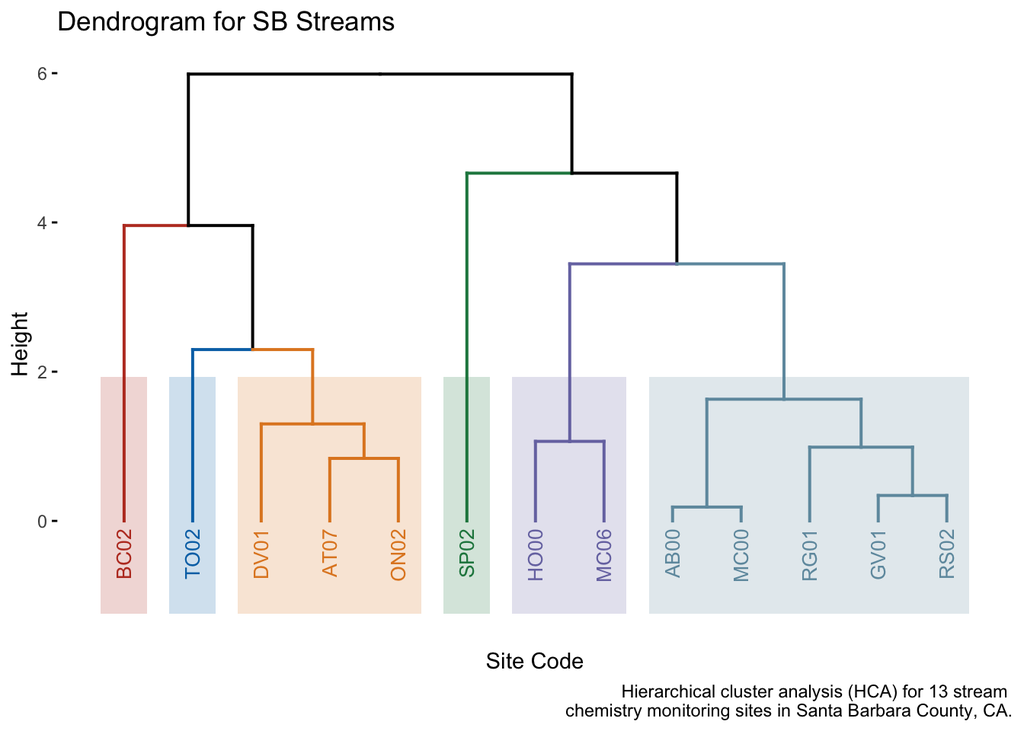

```r
# plotting a dendrogram

# plot(streams_hc_complete, cex = 0.6, hang = -1)

#customize visualization using ggplot and factoextra

# require("ggsci")
# show_col(pal_nejm(palette = c("default"))(10))
# show_col(pal_nejm("default", alpha = 0.6)(10))

fviz_dend(x = streams_hc_complete, cex = 0.7, lwd = 0.7, k = 6,
          k_colors = ("nejm"),
          rect = TRUE,
          rect_border = "nejm",
          rect_fill = TRUE) +
  labs(x = "Site Code",
       y = "Height",
       title = "Dendrogram for SB Streams",
       caption = "Hierarchical cluster analysis (HCA) for 13 stream
       chemistry monitoring sites in Santa Barbara County, CA.")
```

Brief Summary:

- Although these stream sites are all within the same watershed, there is a great variation in the water chemistry, resulting in 6 clusters
- The largest cluster shows us that sites AB00, MC00, RG01, GVO1, and RS02 are the most similar to each other